# 22015791 SUMAN K.C.

## Importing Libraries

```python
#importing pandas, os, matplotlib, sns
import pandas as pd
import os
from matplotlib import pyplot as plt
%matplotlib inline
import seaborn as sns
```

### Data Preperation

1. **Write a python program to merge data from each data from each month into one CSV and read in updated dataframe**

```python
path_dir = './Sales Analysis/'
#looping all the files in sales analysis
for salesfiles in os.listdir(path_dir):
    print(salesfiles)
```

```
Sales_April_2019.csv
Sales_August_2019.csv
Sales_December_2019.csv
Sales_February_2019.csv
Sales_January_2019.csv
Sales_July_2019.csv
Sales_June_2019.csv
Sales_March_2019.csv
Sales_May_2019.csv
Sales_November_2019.csv
Sales_October_2019.csv
Sales_September_2019.csv
```

```python
Sales_DataFrame = pd.DataFrame() # creating new dataframe
for salesfiles in os.listdir(path_dir):
    df = pd.read_csv(path_dir+salesfiles)
    Sales_DataFrame = pd.concat([Sales_DataFrame,df])
```

```python
Sales_DataFrame.head()
```

|  | Order ID | Product | Quantity Ordered | Price Each | Order Date | Purchase Address |
| --- | --- | --- | --- | --- | --- | --- |
| 0 | 176558.0 | USB-C Charging Cable | 2.0 | 11.95 | 4/19/2019 8:46 | 917 1st St, Dallas, TX 75001 |
| 1 | NaN | NaN | NaN | NaN | NaN | NaN |
| 2 | 176559.0 | Bose SoundSport Headphones | 1.0 | 99.99 | 4/7/2019 22:30 | 682 Chestnut St, Boston, MA 02215 |
| 3 | 176560.0 | Google Phone | 1.0 | 600.00 | 4/12/2019 14:38 | 669 Spruce St, Los Angeles, CA 90001 |
| 4 | 176560.0 | Wired Headphones | 1.0 | 11.99 | 4/12/2019 14:38 | 669 Spruce St, Los Angeles, CA 90001 |

### Write a python program to remove the NaN missing values from updated dataframe

```python
Sales_DataFrame.isnull().sum() # here this code count the number of null values
```

```
Order ID            900
Product             900
Quantity Ordered    900
Price Each          900
Order Date          900
Purchase Address    900
dtype: int64
```

```python
Sales_DataFrame = Sales_DataFrame.dropna(how = 'all')
# dropna function is used to drop the null values and the parameter how = all is to delete all the nan values

Sales_DataFrame.shape #this provide row and column
```

```
(185950, 6)
```

```python
Sales_DataFrame.isnull().sum() # checking the null values after removing null values
```

```
Order ID            0
Product             0
Quantity Ordered    0
Price Each          0
Order Date          0
Purchase Address    0
dtype: int64
```

```python
Sales_DataFrame.isna() # checking nan values
```

|  | Order ID | Product | Quantity Ordered | Price Each | Order Date | Purchase Address |
| --- | --- | --- | --- | --- | --- | --- |
| 0 | False | False | False | False | False | False |
| 2 | False | False | False | False | False | False |
| 3 | False | False | False | False | False | False |
| 4 | False | False | False | False | False | False |
| 5 | False | False | False | False | False | False |
| ... | ... | ... | ... | ... | ... | ... |
| 11681 | False | False | False | False | False | False |
| 11682 | False | False | False | False | False | False |
| 11683 | False | False | False | False | False | False |
| 11684 | False | False | False | False | False | False |
| 11685 | False | False | False | False | False | False |

185950 rows × 6 columns

```python
Sales_DataFrame.shape
```

```
(185950, 6)
```

```python
Sales_DataFrame.head()
```

|  | Order ID | Product | Quantity Ordered | Price Each | Order Date | Purchase Address |
| --- | --- | --- | --- | --- | --- | --- |
| 0 | 176558.0 | USB-C Charging Cable | 2.0 | 11.95 | 4/19/2019 8:46 | 917 1st St, Dallas, TX 75001 |
| 2 | 176559.0 | Bose SoundSport Headphones | 1.0 | 99.99 | 4/7/2019 22:30 | 682 Chestnut St, Boston, MA 02215 |
| 3 | 176560.0 | Google Phone | 1.0 | 600.00 | 4/12/2019 14:38 | 669 Spruce St, Los Angeles, CA 90001 |
| 4 | 176560.0 | Wired Headphones | 1.0 | 11.99 | 4/12/2019 14:38 | 669 Spruce St, Los Angeles, CA 90001 |
| 5 | 176561.0 | Wired Headphones | 1.0 | 11.99 | 4/30/2019 9:27 | 333 8th St, Los Angeles, CA 90001 |

### Write a pyton program to convert Quantity Ordered and Price Each to numberic

```python
Sales_DataFrame.dtypes #this function displays the datatypes of column
```

```
Order ID            float64
Product              object
Quantity Ordered    float64
Price Each          float64
Order Date           object
Purchase Address     object
dtype: object
```

```python
#this code convert Quantity Ordered and Price Each datatype to numeric
Sales_DataFrame['Quantity Ordered'] = Sales_DataFrame['Quantity Ordered'].astype(int)
Sales_DataFrame['Price Each'] = Sales_DataFrame['Price Each'].astype(int)
```

```python
#Quantity Ordered and Price each is in numberic data types that is int32
Sales_DataFrame.dtypes
```

```
Order ID            float64
Product              object
Quantity Ordered      int32
Price Each            int32
Order Date           object
Purchase Address     object
dtype: object
```

1. **Create a new column named Month from Ordered Data of Updatedfram and convert it to integer as data type.**

```python
#creating a new column and adding month value from Order Date by splitting and calling by indexing
Sales_DataFrame['Month'] = Sales_DataFrame['Order Date'].str.split('/').str[0]
Sales_DataFrame.head()
```

|  | Order ID | Product | Quantity Ordered | Price Each | Order Date | Purchase Address | Month |
| --- | --- | --- | --- | --- | --- | --- | --- |
| 0 | 176558.0 | USB-C Charging Cable | 2 | 11 | 4/19/2019 8:46 | 917 1st St, Dallas, TX 75001 | 4 |
| 2 | 176559.0 | Bose SoundSport Headphones | 1 | 99 | 4/7/2019 22:30 | 682 Chestnut St, Boston, MA 02215 | 4 |
| 3 | 176560.0 | Google Phone | 1 | 600 | 4/12/2019 14:38 | 669 Spruce St, Los Angeles, CA 90001 | 4 |
| 4 | 176560.0 | Wired Headphones | 1 | 11 | 4/12/2019 14:38 | 669 Spruce St, Los Angeles, CA 90001 | 4 |
| 5 | 176561.0 | Wired Headphones | 1 | 11 | 4/30/2019 9:27 | 333 8th St, Los Angeles, CA 90001 | 4 |

**5 . Create a new column named City from Purchase Address based on the value in updated dataframe**

```python
#creating new column and adding City
Sales_DataFrame['City'] = Sales_DataFrame['Purchase Address'].str.split(',').str[1]
Sales_DataFrame.head()
```

|  | Order ID | Product | Quantity Ordered | Price Each | Order Date | Purchase Address | Month | City |
| --- | --- | --- | --- | --- | --- | --- | --- | --- |
| 0 | 176558.0 | USB-C Charging Cable | 2 | 11 | 4/19/2019 8:46 | 917 1st St, Dallas, TX 75001 | 4 | Dallas |
| 2 | 176559.0 | Bose SoundSport Headphones | 1 | 99 | 4/7/2019 22:30 | 682 Chestnut St, Boston, MA 02215 | 4 | Boston |
| 3 | 176560.0 | Google Phone | 1 | 600 | 4/12/2019 14:38 | 669 Spruce St, Los Angeles, CA 90001 | 4 | Los Angeles |
| 4 | 176560.0 | Wired Headphones | 1 | 11 | 4/12/2019 14:38 | 669 Spruce St, Los Angeles, CA 90001 | 4 | Los Angeles |
| 5 | 176561.0 | Wired Headphones | 1 | 11 | 4/30/2019 9:27 | 333 8th St, Los Angeles, CA 90001 | 4 | Los Angeles |

### Data Analysis

**1. Write a Python program to show summary statistics of sum, mean, standard deviation, skewness, and kurtosis of any chosen variable**

```python
Sales_DataFrame.head()
```

|  | Order ID | Product | Quantity Ordered | Price Each | Order Date | Purchase Address | Month | City |
| --- | --- | --- | --- | --- | --- | --- | --- | --- |
| 0 | 176558.0 | USB-C Charging Cable | 2 | 11 | 4/19/2019 8:46 | 917 1st St, Dallas, TX 75001 | 4 | Dallas |
| 2 | 176559.0 | Bose SoundSport Headphones | 1 | 99 | 4/7/2019 22:30 | 682 Chestnut St, Boston, MA 02215 | 4 | Boston |
| 3 | 176560.0 | Google Phone | 1 | 600 | 4/12/2019 14:38 | 669 Spruce St, Los Angeles, CA 90001 | 4 | Los Angeles |
| 4 | 176560.0 | Wired Headphones | 1 | 11 | 4/12/2019 14:38 | 669 Spruce St, Los Angeles, CA 90001 | 4 | Los Angeles |
| 5 | 176561.0 | Wired Headphones | 1 | 11 | 4/30/2019 9:27 | 333 8th St, Los Angeles, CA 90001 | 4 | Los Angeles |

```python
Quantity_Ordered_sum =Sales_DataFrame['Quantity Ordered'].sum()
Quantity_Ordered_mean =Sales_DataFrame['Quantity Ordered'].mean()
Quantity_Ordered_std =Sales_DataFrame['Quantity Ordered'].std()
Quantity_Ordered_skew =Sales_DataFrame['Quantity Ordered'].skew()
Quantity_Ordered_kurt =Sales_DataFrame['Quantity Ordered'].kurt()
```

```python
print("summary statistics of sum, mean, standard deviation, skewness, and kurtosis of Quantity Ordered")
print('')
print('The Sum of Quantity Ordered is:',Quantity_Ordered_sum)
print("The Kurtosis of Quantity Ordered is:",Quantity_Ordered_skew)
print("The SKewness of Quantity Ordered is::",Quantity_Ordered_kurt)
print("The Mean of Quantity Ordered is::",Quantity_Ordered_mean,)
print("The Standard of Quantity Ordered is::",Quantity_Ordered_std)
```

[output not shown]

**2.Write a Python program to calculate and show correlation of all variables**

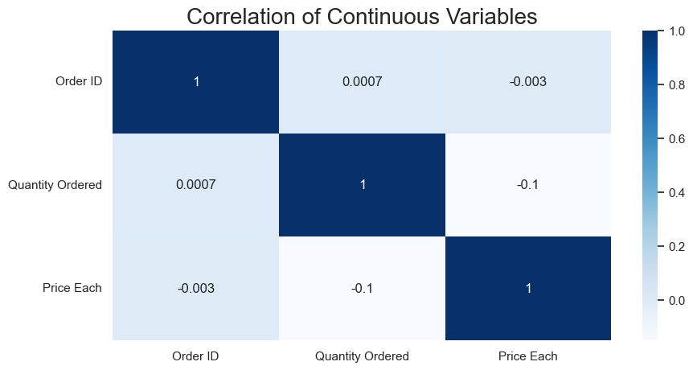

```python
plt.figure(figsize =(10,5)) # setting figuresize
sns.set_theme(style = 'white') # setting theme to white
continuous_variables = ["Order ID", "Quantity Ordered", "Price Each"]
correlation = Sales_DataFrame[continuous_variables].corr() # calculating correlation of continuous variables
heatmap = sns.heatmap(data=correlation, annot = True, cmap='Blues', fmt = '.1g')
plt.yticks(rotation = 0)
plt.title("Correlation of Continuous Variables", fontsize = 20)
plt.show()
```

## Data Expolaration

**1. Which Month has the best sales? and how much was the earning in that month? Make a bar graph of sales as well**

```python
#calculating the best sales by multiplying Quantity Ordered and Price Each and storing it in Sales Column
Sales_DataFrame['Sales'] = Sales_DataFrame['Quantity Ordered']* Sales_DataFrame['Price Each']
Sales_DataFrame.head()
```

|  | Order ID | Product | Quantity Ordered | Price Each | Order Date | Purchase Address | Month | City | Sales |
| --- | --- | --- | --- | --- | --- | --- | --- | --- | --- |
| 0 | 176558.0 | USB-C Charging Cable | 2 | 11 | 4/19/2019 8:46 | 917 1st St, Dallas, TX 75001 | 4 | Dallas | 22 |
| 2 | 176559.0 | Bose SoundSport Headphones | 1 | 99 | 4/7/2019 22:30 | 682 Chestnut St, Boston, MA 02215 | 4 | Boston | 99 |
| 3 | 176560.0 | Google Phone | 1 | 600 | 4/12/2019 14:38 | 669 Spruce St, Los Angeles, CA 90001 | 4 | Los Angeles | 600 |
| 4 | 176560.0 | Wired Headphones | 1 | 11 | 4/12/2019 14:38 | 669 Spruce St, Los Angeles, CA 90001 | 4 | Los Angeles | 11 |
| 5 | 176561.0 | Wired Headphones | 1 | 11 | 4/30/2019 9:27 | 333 8th St, Los Angeles, CA 90001 | 4 | Los Angeles | 11 |

```python
Sales_DataFrame['Month'] = Sales_DataFrame['Month'].astype(int)
Sales = Sales_DataFrame.groupby('Month')['Sales'].sum()
Sales
```

```
Month
1     1813956
2     2191696
3     2794068
4     3374951
5     3138287
6     2566187
7     2635443
8     2234194
9     2087435
10    3719205
11    3184394
12    4591824
Name: Sales, dtype: int32
```

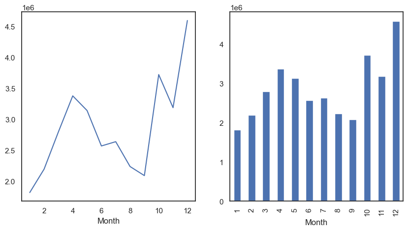

```python
fig = plt.figure(figsize=(10,5)) #setting figure size
# first plot
ax1 = fig.add_subplot(1,2,1)

Sales_DataFrame.groupby('Month')['Sales'].sum().plot(kind = 'line', ax = ax1)
# second plot
ax2 = fig.add_subplot(1,2,2)
Sales_DataFrame.groupby('Month')['Sales'].sum().plot(kind = 'bar', ax = ax2)

plt.show()
```

**2. Which city has highest product**

```python
#counting the unique values
Sales_DataFrame['City'].value_counts()
```

```
 San Francisco    44732
 Los Angeles      29605
 New York City    24876
 Boston           19934
 Atlanta          14881
 Dallas           14820
 Seattle          14732
 Portland         12465
 Austin            9905
Name: City, dtype: int64
```

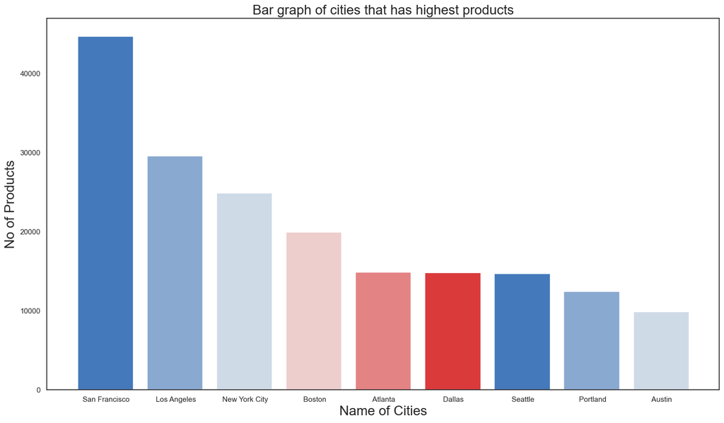

```python
# setting figure size
plt.figure(figsize=(18,10))
#creating bar
colors = sns.diverging_palette(250, 12) #using seaborn color palette

plt.bar(list(Sales_DataFrame['City'].value_counts()[0:9].keys()),list(Sales_DataFrame['City'].value_counts()[0:9]),
        color=colors)
plt.title("Bar graph of cities that has highest products",fontsize= 20)
plt.ylabel("No of Products",fontsize= 20)
plt.xlabel("Name of Cities", fontsize= 20)
plt.show()
```

**3. Which product was sold the most in overall? Illustrate it through bar graph.**

```python
#counting the unique values
Sales_DataFrame['Product'].value_counts()
```

```
USB-C Charging Cable          21903
Lightning Charging Cable      21658
AAA Batteries (4-pack)        20641
AA Batteries (4-pack)         20577
Wired Headphones              18882
Apple Airpods Headphones      15549
Bose SoundSport Headphones    13325
27in FHD Monitor               7507
iPhone                         6842
27in 4K Gaming Monitor         6230
34in Ultrawide Monitor         6181
Google Phone                   5525
Flatscreen TV                  4800
Macbook Pro Laptop             4724
ThinkPad Laptop                4128
20in Monitor                   4101
Vareebadd Phone                2065
LG Washing Machine              666
LG Dryer                        646
Name: Product, dtype: int64
```

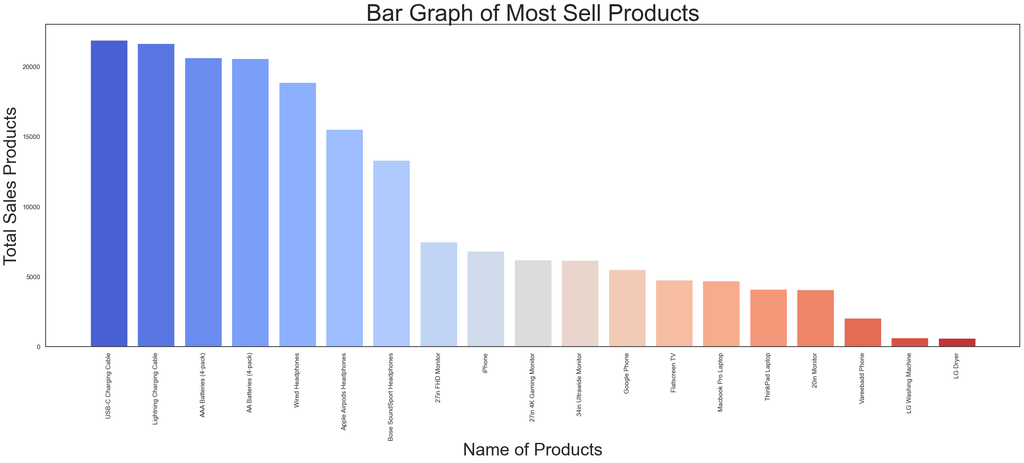

```python
plt.figure(figsize=(30,10)) # Setting figure size
colors = sns.color_palette("coolwarm", 19) # seaborn color pallete is used to generate unique color
#using matplotlib generating bar graph and setting seaborn color
plt.bar(list(Sales_DataFrame['Product'].value_counts()[0:19].keys()),list(Sales_DataFrame['Product'].value_counts()[0:19]),
        color= colors, linewidth=2)
plt.xticks(rotation = 90)
plt.title("Bar Graph of Most Sell Products", fontsize = 40)
plt.ylabel("Total Sales Products", fontsize = 30)
plt.xlabel("Name of Products", fontsize = 30)
plt.show()
```

**4. Write a Python program to show histogram plot of any chosen variables. Use proper labels in the grap**

```python
Sales_DataFrame.head()
```

|  | Order ID | Product | Quantity Ordered | Price Each | Order Date | Purchase Address | Month | City | Sales |
| --- | --- | --- | --- | --- | --- | --- | --- | --- | --- |
| 0 | 176558.0 | USB-C Charging Cable | 2 | 11 | 4/19/2019 8:46 | 917 1st St, Dallas, TX 75001 | 4 | Dallas | 22 |
| 2 | 176559.0 | Bose SoundSport Headphones | 1 | 99 | 4/7/2019 22:30 | 682 Chestnut St, Boston, MA 02215 | 4 | Boston | 99 |
| 3 | 176560.0 | Google Phone | 1 | 600 | 4/12/2019 14:38 | 669 Spruce St, Los Angeles, CA 90001 | 4 | Los Angeles | 600 |
| 4 | 176560.0 | Wired Headphones | 1 | 11 | 4/12/2019 14:38 | 669 Spruce St, Los Angeles, CA 90001 | 4 | Los Angeles | 11 |
| 5 | 176561.0 | Wired Headphones | 1 | 11 | 4/30/2019 9:27 | 333 8th St, Los Angeles, CA 90001 | 4 | Los Angeles | 11 |

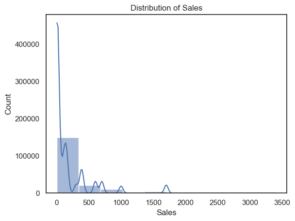

```python
sns.histplot(Sales_DataFrame['Sales'], bins=10, kde=True)#seaborn histogram is used to calculate the histogram of Sales
plt.xlabel('Sales')
plt.ylabel('Count')
plt.title('Distribution of Sales')
plt.show()
```